# INTRODUCTION:

```
    The field of human resources analysis, which can be understood as an approach to human resources management focused on data and analytical thinking, is quickly becoming an indispensable part of organizational configurations. In this article, I will introduce you to a data science project on Human Resource Analysis with Python.
```

# OBJECTIVE:

The objective is to do apply to python and Exploratory Data Analytics and apply to testing of hypothesis and to influnce by the in candidate joined or not joined.

# DataSet Description:

● Sno: Sl number auto increment ● Candidate_Ref: Candidate reference number ● DOJ_Extended: Date of Joining of extended ● Duration_to_accept offer: Duration to accept the offer by candidate ● Notice_Period: Notice period of previous employer ● Offered_Band: E1 < E2 < E3 and so on ● Percent_hike_expected_in_CTC: expected hike by candidate ● Percent_hike_offered_in_CTC: hike offered by joining organisation ● Percent_difference_CTC: difference between expected and offered ● Joining_Bonus: any joining bonus offered. ● Candidate_relocate_actual: relocating required or not ● Gender: Gender of candidate ● Candidate_Source: How candidate applied or reached ● Rex_in_Yrs: years of exp ● Postal_Code : Postal Code of the area of organisation ● Domicile: Name of Home state ● Location: Name of the location ● Region_Name: Name of the Region ● Age: Age of candidate ● Date_of_Interview : Date on which Interview was conducted. ● LOB: Line of business

# TARGET VARIABLE

Status: joined or notINSIGHTS DATA: Number of Attribute:23 Target Attribute: Status

# Requirement:

Basic Libaries:

Numpy: NumPy is a library for the Python programming language, adding support for large, multi-dimensional arrays and matrices, along with a large collection of high-level mathematical functions to operate on these arrays.

Pandas: In computer programming, pandas is a software library written for the Python programming language for data manipulation and analysis. In particular, it offers data structures and operations for manipulating numerical tables and time series. It is free software released under the three-clause BSD license.

Seaborn: Seaborn is a Python data visualization library based on matplotlib. It provides a high-level interface for drawing attractive and informative statistical graphics.

Matplotlib: Matplotlib is a plotting library for the Python programming language and its numerical mathematics extension NumPy. It provides an object-oriented API for embedding plots into applications using general-purpose GUI toolkits.

# BASIC LIBIRIES

```python
import pandas as pd
import numpy as np
import seaborn as sns
import matplotlib.pyplot as plt
```

```python
df = pd.read_csv(r"C:\Users\User\Desktop\HRData.csv")
df
```

|  | Unnamed: 0 | Sno | Candidate_Ref | DOJ_Extended | Duration_to_accept_offer | Notice_Period | Offered_Band | Percent_hike_expected_in_CTC | Percent_hike_offered_in_CTC | Percent_difference_CTC | ... | Candidate_Source | Rex_in_Yrs | Postal_Code | Age | Domicile_Name | Date_of_Interview | Status | LOB | Location | Region_Name |
| --- | --- | --- | --- | --- | --- | --- | --- | --- | --- | --- | --- | --- | --- | --- | --- | --- | --- | --- | --- | --- | --- |
| 0 | 0 | 1 | 2110407 | Yes | 14 | 30 | E2 | -20.79 | 13.16 | 42.86 | ... | Agency | 7 | 201301 | 34.0 | Goa | 08-01-2013 | Joined | ERS | Noida | North |
| 1 | 1 | 195 | 2605197 | No | 1 | 60 | E1 | 40.35 | 31.58 | -6.25 | ... | Employee Referral | 1 | 201301 | 25.0 | Goa | 17-04-2013 | Joined | ERS | Noida | North |
| 2 | 2 | 588 | 2127782 | No | 17 | 30 | E3 | 20.00 | 20.00 | 0.00 | ... | Direct | 10 | 201301 | 36.0 | Goa | 20-05-2014 | Joined | ERS | Noida | North |
| 3 | 3 | 632 | 2138445 | No | 2 | 30 | E1 | 132.45 | 42.86 | -38.54 | ... | Direct | 4 | 201301 | 30.0 | Goa | 29-06-2014 | Joined | ERS | Noida | North |
| 4 | 4 | 688 | 2150946 | Yes | 4 | 30 | E1 | 22.22 | -23.33 | -37.27 | ... | Agency | 2 | 201301 | 26.0 | Goa | 11-04-2014 | Joined | ERS | Noida | North |
| ... | ... | ... | ... | ... | ... | ... | ... | ... | ... | ... | ... | ... | ... | ... | ... | ... | ... | ... | ... | ... | ... |
| 8990 | 8990 | 10033 | 3393127 | No | 1 | 0 | E1 | 42.86 | 42.86 | 0.00 | ... | Employee Referral | 2 | 382460 | 34.0 | Kerala | 01-07-2014 | Joined | INFRA | NaN | NaN |
| 8991 | 8991 | 3893 | 2419919 | Yes | 20 | 30 | E1 | 6.48 | 6.48 | 0.00 | ... | Direct | 5 | 411006 | 31.0 | Haryana | 25-10-2013 | Joined | INFRA | NaN | NaN |
| 8992 | 8992 | 8977 | 3304772 | Yes | 0 | 30 | E1 | 48.15 | 57.41 | 6.25 | ... | Employee Referral | 2 | 400001 | 27.0 | Haryana | 22-12-2013 | Joined | INFRA | NaN | NaN |
| 8993 | 8993 | 11222 | 3544858 | No | 13 | 30 | E1 | 67.08 | 42.86 | -14.50 | ... | Direct | 4 | 700027 | 34.0 | Punjab | 26-05-2013 | Joined | INFRA | NaN | NaN |
| 8994 | 8994 | 594 | 2128714 | Yes | 41 | 45 | E1 | 20.00 | 4.00 | -13.33 | ... | Direct | 5 | 560002 | 33.0 | Bihar | 24-05-2014 | Joined | AXON | NaN | NaN |

8995 rows × 23 columns

```python
#checking shape:
df.shape
```

```
(8995, 23)
```

```python
df.duplicated().sum()
```

```
0
```

```python
df.isnull().sum()/df.shape[0]*100
```

```
Unnamed: 0                      0.000000
Sno                             0.000000
Candidate_Ref                   0.000000
DOJ_Extended                    0.000000
Duration_to_accept_offer        0.000000
Notice_Period                   0.000000
Offered_Band                    0.144525
Percent_hike_expected_in_CTC    0.000000
Percent_hike_offered_in_CTC     0.000000
Percent_difference_CTC          0.000000
Joining_Bonus                   0.000000
Candidate_relocate_actual       0.000000
Gender                          0.000000
Candidate_Source                0.000000
Rex_in_Yrs                      0.000000
Postal_Code                     0.000000
Age                             0.166759
Domicile_Name                   0.000000
Date_of_Interview               0.000000
Status                          0.000000
LOB                             0.000000
Location                        0.144525
Region_Name                     0.144525
dtype: float64
```

1. How many missing values

```python
df.isnull().sum()
```

```
Unnamed: 0                       0
Sno                              0
Candidate_Ref                    0
DOJ_Extended                     0
Duration_to_accept_offer         0
Notice_Period                    0
Offered_Band                    13
Percent_hike_expected_in_CTC     0
Percent_hike_offered_in_CTC      0
Percent_difference_CTC           0
Joining_Bonus                    0
Candidate_relocate_actual        0
Gender                           0
Candidate_Source                 0
Rex_in_Yrs                       0
Postal_Code                      0
Age                             15
Domicile_Name                    0
Date_of_Interview                0
Status                           0
LOB                              0
Location                        13
Region_Name                     13
dtype: int64
```

```python
df.info()
```

```
<class 'pandas.core.frame.DataFrame'>
RangeIndex: 8995 entries, 0 to 8994
Data columns (total 23 columns):
 #   Column                        Non-Null Count  Dtype
---  ------                        --------------  -----
 0   Unnamed: 0                    8995 non-null   int64
 1   Sno                           8995 non-null   int64
 2   Candidate_Ref                 8995 non-null   int64
 3   DOJ_Extended                  8995 non-null   object
 4   Duration_to_accept_offer      8995 non-null   int64
 5   Notice_Period                 8995 non-null   int64
 6   Offered_Band                  8982 non-null   object
 7   Percent_hike_expected_in_CTC  8995 non-null   float64
 8   Percent_hike_offered_in_CTC   8995 non-null   float64
 9   Percent_difference_CTC        8995 non-null   float64
 10  Joining_Bonus                 8995 non-null   object
 11  Candidate_relocate_actual     8995 non-null   object
 12  Gender                        8995 non-null   object
 13  Candidate_Source              8995 non-null   object
 14  Rex_in_Yrs                    8995 non-null   int64
 15  Postal_Code                   8995 non-null   int64
 16  Age                           8980 non-null   float64
 17  Domicile_Name                 8995 non-null   object
 18  Date_of_Interview             8995 non-null   object
 19  Status                        8995 non-null   object
 20  LOB                           8995 non-null   object
 21  Location                      8982 non-null   object
 22  Region_Name                   8982 non-null   object
dtypes: float64(4), int64(7), object(12)
memory usage: 1.6+ MB
```

```python
#Cheking dtype of each attribute:
df.info()
```

```
<class 'pandas.core.frame.DataFrame'>
RangeIndex: 8995 entries, 0 to 8994
Data columns (total 23 columns):
 #   Column                        Non-Null Count  Dtype
---  ------                        --------------  -----
 0   Unnamed: 0                    8995 non-null   int64
 1   Sno                           8995 non-null   int64
 2   Candidate_Ref                 8995 non-null   int64
 3   DOJ_Extended                  8995 non-null   object
 4   Duration_to_accept_offer      8995 non-null   int64
 5   Notice_Period                 8995 non-null   int64
 6   Offered_Band                  8982 non-null   object
 7   Percent_hike_expected_in_CTC  8995 non-null   float64
 8   Percent_hike_offered_in_CTC   8995 non-null   float64
 9   Percent_difference_CTC        8995 non-null   float64
 10  Joining_Bonus                 8995 non-null   object
 11  Candidate_relocate_actual     8995 non-null   object
 12  Gender                        8995 non-null   object
 13  Candidate_Source              8995 non-null   object
 14  Rex_in_Yrs                    8995 non-null   int64
 15  Postal_Code                   8995 non-null   int64
 16  Age                           8980 non-null   float64
 17  Domicile_Name                 8995 non-null   object
 18  Date_of_Interview             8995 non-null   object
 19  Status                        8995 non-null   object
 20  LOB                           8995 non-null   object
 21  Location                      8982 non-null   object
 22  Region_Name                   8982 non-null   object
dtypes: float64(4), int64(7), object(12)
memory usage: 1.6+ MB
```

```python
def missingval(df):
    missvalcount = df.isnull().sum()
    missvalpercent = df.isnull().sum()/df.shape[0]*100
    newdf = pd.concat([missvalcount,missvalpercent],axis=1)
    newdf1 = newdf.rename(columns={0:'missvalcount',1:'missval %'})
    newdf1 =newdf1[newdf1['missvalcount']!=0].sort_values(by='missvalcount',ascending=False)
    return newdf1
```

```python
missingval(df)
```

|  | missvalcount | missval % |
| --- | --- | --- |
| Age | 15 | 0.166759 |
| Offered_Band | 13 | 0.144525 |
| Location | 13 | 0.144525 |
| Region_Name | 13 | 0.144525 |

```python
! pip install missingno
```

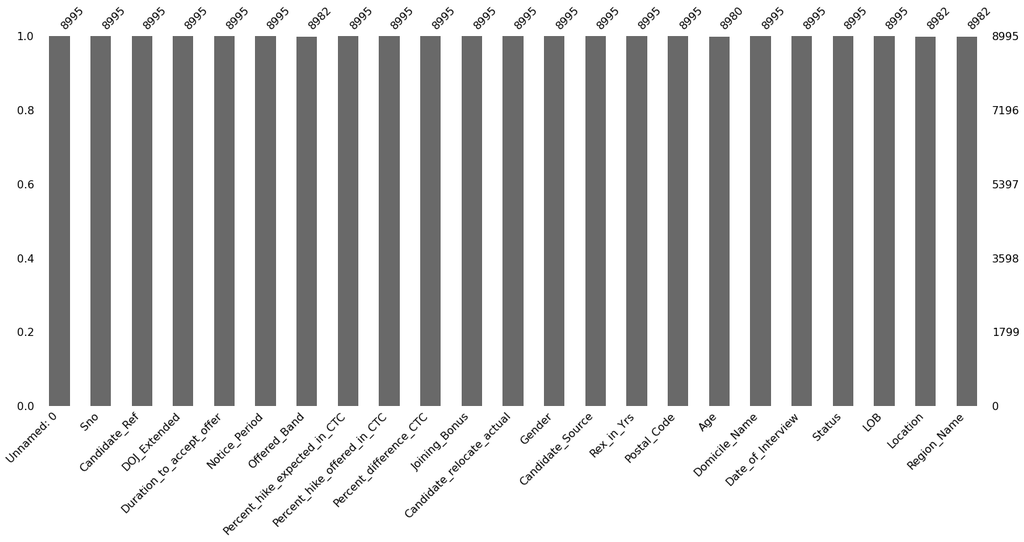

```python
import missingno as ms
ms.bar(df)
```

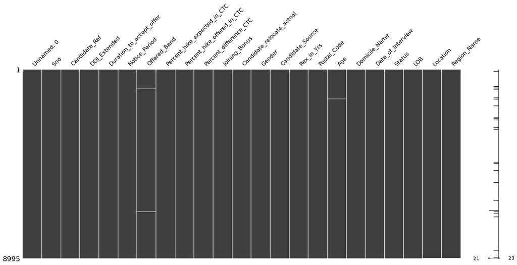

```python
ms.matrix(df)
```

2.Treat Missing Values

```python
# Numerical columns
# Replace with mean
# Replace with median
# Mean=Median-----Normal
# Mean>Median---Right skeweed
# Mean<Median---Left skeweed
```

```python
df['Offered_Band'].value_counts()
```

```
E1    5565
E2    2704
E3     502
E0     211
Name: Offered_Band, dtype: int64
```

```python
df['Offered_Band']=df['Offered_Band'].fillna(df['Offered_Band'].mode()[0])
missingval(df)
```

|  | missvalcount | missval % |
| --- | --- | --- |
| Age | 15 | 0.166759 |
| Location | 13 | 0.144525 |
| Region_Name | 13 | 0.144525 |

```python
df['Age'].describe()
```

```
count    8980.000000
mean       29.912027
std         4.095699
min        20.000000
25%        27.000000
50%        29.000000
75%        34.000000
max        60.000000
Name: Age, dtype: float64
```

Mean inputation

```python
df['Age'].fillna(df['Age'].mean(),inplace=True)
missingval(df)
```

|  | missvalcount | missval % |
| --- | --- | --- |
| Location | 13 | 0.144525 |
| Region_Name | 13 | 0.144525 |

```python
df['Location'].value_counts()
```

```
Chennai      3150
Noida        2727
Bangalore    2230
Hyderabad     341
Mumbai        197
Gurgaon       146
Kolkata       129
Pune           48
Cochin          8
Ahmedabad       6
Name: Location, dtype: int64
```

```python
df['Location']=df['Location'].fillna(df['Location'].mode()[0])
missingval(df)
```

|  | missvalcount | missval % |
| --- | --- | --- |
| Region_Name | 13 | 0.144525 |

```python
df['Region_Name']=df['Region_Name'].fillna(df['Region_Name'].mode()[0])
missingval(df)
```

|  | missvalcount | missval % |
| --- | --- | --- |

```python
 df.isnull().sum()
```

```
Unnamed: 0                      0
Sno                             0
Candidate_Ref                   0
DOJ_Extended                    0
Duration_to_accept_offer        0
Notice_Period                   0
Offered_Band                    0
Percent_hike_expected_in_CTC    0
Percent_hike_offered_in_CTC     0
Percent_difference_CTC          0
Joining_Bonus                   0
Candidate_relocate_actual       0
Gender                          0
Candidate_Source                0
Rex_in_Yrs                      0
Postal_Code                     0
Age                             0
Domicile_Name                   0
Date_of_Interview               0
Status                          0
LOB                             0
Location                        0
Region_Name                     0
dtype: int64
```

# TASK 1:Data Manipulation using Python

1.Analysis of percentage joined of offer released.

```python
(df['Status']=='Joined').sum()/df.shape[0]*100
```

```
81.30072262367982
```

INSIGHTS: 81 percentage joined of offer released.

2.What are the key drivers that influence the candidate joining/not joining a company?

```python
df.groupby("Status",as_index=False).aggregate({'Percent_hike_expected_in_CTC':'sum','Percent_hike_offered_in_CTC':'sum','Percent_difference_CTC':'sum'}).T
```

|  | 0 | 1 |
| --- | --- | --- |
| Status | Joined | Not Joined |
| Percent_hike_expected_in_CTC | 320753.01 | 73810.9 |
| Percent_hike_offered_in_CTC | 300807.13 | 64905.79 |
| Percent_difference_CTC | -9229.27 | -4927.08 |

Most of the cannidate key drivers that influnce the candidate joining.

1. Are there specific locations where candidates are not joining?

```python
df[df['Status']=='Not Joined']['Location'].value_counts().nlargest(5)
```

```
Chennai      664
Bangalore    488
Noida        365
Hyderabad     75
Kolkata       29
Name: Location, dtype: int64
```

INSIGHTS: Most of the candidates not joined in chennai

4.Joining status depends on the duration to accept an offer?

```python
df.groupby('Status',as_index=False)['Duration_to_accept_offer'].sum()
```

|  | Status | Duration_to_accept_offer |
| --- | --- | --- |
| 0 | Joined | 150826 |
| 1 | Not Joined | 41977 |

INSIGHTS: Maximum of the candidate Joining status depends on the duration to accept an offer

5.Hike offered has an impact on joining status.?

```python
df.groupby('Status',as_index=False)['Percent_hike_offered_in_CTC'].mean()
```

|  | Status | Percent_hike_offered_in_CTC |
| --- | --- | --- |
| 0 | Joined | 41.133205 |
| 1 | Not Joined | 38.588460 |

6.How many canntidates relocate required or not ?

```python
pd.crosstab(df['Candidate_relocate_actual'],df['Location'],normalize=True)
```

| Location Candidate_relocate_actual | Ahmedabad | Bangalore | Chennai | Cochin | Gurgaon | Hyderabad | Kolkata | Mumbai | Noida | Pune |
| --- | --- | --- | --- | --- | --- | --- | --- | --- | --- | --- |
| No | 0.000445 | 0.228680 | 0.287686 | 0.000891 | 0.014696 | 0.033957 | 0.012358 | 0.020931 | 0.252505 | 0.004453 |
| Yes | 0.000223 | 0.019595 | 0.063015 | 0.000000 | 0.001559 | 0.004008 | 0.002004 | 0.001002 | 0.051102 | 0.000891 |

7.How much Percent hike expected by candidate?

```python
df.Percent_hike_expected_in_CTC.mean()
```

```
43.86480377987739
```

8.which locations where candidate mostly joined?

```python
df[df['Status']=='Joined']['Location'].value_counts()
```

```
Chennai      2499
Noida        2362
Bangalore    1742
Hyderabad     266
Mumbai        176
Gurgaon       118
Kolkata       100
Pune           38
Cochin          7
Ahmedabad       5
Name: Location, dtype: int64
```

INSIGHTS: Candidate mostly joining in chennai.

8.joining status depends on the any bonus offerd?

```python
df.query("Joining_Bonus== 'Yes' & Status == 'Joined'").shape[0]
```

```
336
```

INSIGHTS: 336 candidate depends on the binus offerd.

```python
df[df['Status']=='Not Joined']['Age'].value_counts().nlargest(1)
```

```
34.0    312
Name: Age, dtype: int64
```

10.expected hike by candidate offered has an impact on joining status.?

```python
df.groupby('Status',as_index=False)['Percent_hike_expected_in_CTC'].mean()
```

|  | Status | Percent_hike_expected_in_CTC |
| --- | --- | --- |
| 0 | Joined | 43.860660 |
| 1 | Not Joined | 43.882818 |

11.How many candidates DOJ_Extended?

```python
df.DOJ_Extended.value_counts()
```

```
No     4788
Yes    4207
Name: DOJ_Extended, dtype: int64
```

INSIGHTS: 4207 Candidates are asking DOJ_Extended.

# Task 1.2 (Statistical Analysis using Python)

o Descriptive statistics for both numerical and categorical and draw few insights from them.

o Perform relevant hypothesis testing (t, chi-Square, Anova tests)

#HYPOTHESIS TEST: #PARAMETRIC TEST: 1.Z_test 2.paired t test 3.two sample t test 4.one way anova 5.two way anova #NON PARAMETRIC TEST: 1.Wilcoxon signed rank 2.Mann-Whitney 3.Kruskal-Wallis 4.Friedman 5.Chi-square test of independence

# Hypothesis statement:

1. To verify the Joining_Bonus and Status impact the candidate joined or not joined.
2. To verify Candidate_relocate_actual and Status influnece by candidate joined or not joined.
3. To verify Notice_Period and Status.
4. To verify Location and Status.
5. To verify Duration_to_accept_offer and Status impact the candidate joined or not joined.

```python
import pandas as pd
import numpy as np
import matplotlib.pyplot as plt
import seaborn as sns
import scipy.stats as st
import statsmodels.stats as stm
```

```python
df = pd.read_csv(r"C:\Users\User\Desktop\HRData.csv")
df
```

|  | Unnamed: 0 | Sno | Candidate_Ref | DOJ_Extended | Duration_to_accept_offer | Notice_Period | Offered_Band | Percent_hike_expected_in_CTC | Percent_hike_offered_in_CTC | Percent_difference_CTC | ... | Candidate_Source | Rex_in_Yrs | Postal_Code | Age | Domicile_Name | Date_of_Interview | Status | LOB | Location | Region_Name |
| --- | --- | --- | --- | --- | --- | --- | --- | --- | --- | --- | --- | --- | --- | --- | --- | --- | --- | --- | --- | --- | --- |
| 0 | 0 | 1 | 2110407 | Yes | 14 | 30 | E2 | -20.79 | 13.16 | 42.86 | ... | Agency | 7 | 201301 | 34.0 | Goa | 08-01-2013 | Joined | ERS | Noida | North |
| 1 | 1 | 195 | 2605197 | No | 1 | 60 | E1 | 40.35 | 31.58 | -6.25 | ... | Employee Referral | 1 | 201301 | 25.0 | Goa | 17-04-2013 | Joined | ERS | Noida | North |
| 2 | 2 | 588 | 2127782 | No | 17 | 30 | E3 | 20.00 | 20.00 | 0.00 | ... | Direct | 10 | 201301 | 36.0 | Goa | 20-05-2014 | Joined | ERS | Noida | North |
| 3 | 3 | 632 | 2138445 | No | 2 | 30 | E1 | 132.45 | 42.86 | -38.54 | ... | Direct | 4 | 201301 | 30.0 | Goa | 29-06-2014 | Joined | ERS | Noida | North |
| 4 | 4 | 688 | 2150946 | Yes | 4 | 30 | E1 | 22.22 | -23.33 | -37.27 | ... | Agency | 2 | 201301 | 26.0 | Goa | 11-04-2014 | Joined | ERS | Noida | North |
| ... | ... | ... | ... | ... | ... | ... | ... | ... | ... | ... | ... | ... | ... | ... | ... | ... | ... | ... | ... | ... | ... |
| 8990 | 8990 | 10033 | 3393127 | No | 1 | 0 | E1 | 42.86 | 42.86 | 0.00 | ... | Employee Referral | 2 | 382460 | 34.0 | Kerala | 01-07-2014 | Joined | INFRA | NaN | NaN |
| 8991 | 8991 | 3893 | 2419919 | Yes | 20 | 30 | E1 | 6.48 | 6.48 | 0.00 | ... | Direct | 5 | 411006 | 31.0 | Haryana | 25-10-2013 | Joined | INFRA | NaN | NaN |
| 8992 | 8992 | 8977 | 3304772 | Yes | 0 | 30 | E1 | 48.15 | 57.41 | 6.25 | ... | Employee Referral | 2 | 400001 | 27.0 | Haryana | 22-12-2013 | Joined | INFRA | NaN | NaN |
| 8993 | 8993 | 11222 | 3544858 | No | 13 | 30 | E1 | 67.08 | 42.86 | -14.50 | ... | Direct | 4 | 700027 | 34.0 | Punjab | 26-05-2013 | Joined | INFRA | NaN | NaN |
| 8994 | 8994 | 594 | 2128714 | Yes | 41 | 45 | E1 | 20.00 | 4.00 | -13.33 | ... | Direct | 5 | 560002 | 33.0 | Bihar | 24-05-2014 | Joined | AXON | NaN | NaN |

8995 rows × 23 columns

```python
df.describe(include='float').T
```

[output not shown]

```python
df.describe(include='object').T
```

|  | count | unique | top | freq |
| --- | --- | --- | --- | --- |
| DOJ_Extended | 8995 | 2 | No | 4788 |
| Offered_Band | 8982 | 4 | E1 | 5565 |
| Joining_Bonus | 8995 | 2 | No | 8578 |
| Candidate_relocate_actual | 8995 | 2 | No | 7705 |
| Gender | 8995 | 2 | Male | 7444 |
| Candidate_Source | 8995 | 3 | Direct | 4801 |
| Domicile_Name | 8995 | 24 | Haryana | 402 |
| Date_of_Interview | 8995 | 499 | 29-09-2013 | 51 |
| Status | 8995 | 2 | Joined | 7313 |
| LOB | 8995 | 9 | INFRA | 2850 |
| Location | 8982 | 10 | Chennai | 3150 |
| Region_Name | 8982 | 4 | South | 5729 |

1. To verify the Joining_Bonus and Status impact the candidate joined or not joined.

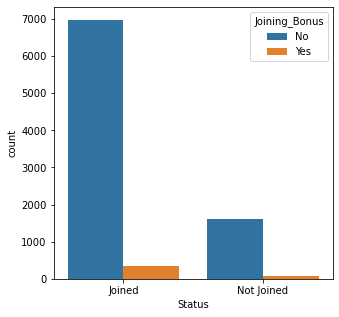

```python
plt.figure(figsize = (5,5))
sns.countplot(x='Status',hue='Joining_Bonus',data=df)
plt.show()
```